# blaklaybul

```python
import os
import time
import json

import requests
import pandas as pd
from elasticsearch import Elasticsearch, helpers

from process import process_data
from graphing import MLBGrapher
```

# 2018 MLB Pitch/fx data

PITCHf/x, created and maintained by Sportvision, is a system that tracks the speeds and trajectories of pitched baseballs. This system, which made its debut in the 2006 MLB playoffs, is installed in every MLB stadium. The data from the system is often used by broadcasters to show a visual representation of the pitch and whether or not a pitch entered the strike-zone. PITCHf/x is also used to determine the type of pitch thrown, such as a fastball, curve, or slider. MLB uses the data from PITCHf/x in its Zone Evaluation System which is used to grade and provide feedback to umpires. Sabermetric analysts note that umpire accuracy has improved after the technology was introduced to MLB.

This dataset was collected from [baseball savant](https://baseballsavant.mlb.com/) and contains every pitch thrown during the 2018 baseball season.

In total, this dataset contains:

| Total Games | 2,397 |
| --- | --- |
| Unique Pitchers | 799 |
| Unique Batters | 990 |
| Total Pitches | 721,190 |
| Total At Bats | 182,352 |
| Total Strikeouts | 41,043 |

Each pitch contains a number of different attributes including:

- the pitcher's name and associated attributes
- the batter's name and associated attributes
- pitch type
- outcome
- pitch speed
- pitch rotation
- exit velocity of batted ball
- launch angle of batted ball
- fielders and field alignment

The full data dictionary can be found [here](https://baseballsavant.mlb.com/csv-docs)

# Analysis Goals

What made a pitch an outlier last year? In 2018, there were more strikeouts than hits for the first time ever in the history of baseball. 2018 also saw over 1000 pitches recorded at 100mph or more and breaking balls continued to take up an increased percentage of balls thrown.

So, hitters are striking out more. Could this be a result of an increase in the pitch speed, an unexpected over-reliance on breaking balls, or something else? **In this analysis, we will try to detemine what pysical factors best make a pitch unique. Along the way, we will investigate individual pitchers and highlighted at-bats.**

We will be focusing on the following features:

- pfx_x - horizontal movement
- pfx_z - vertical movement
- release_speed
- release_spin_rate

# Data Exploration

## Load and Clean

First, load the data from files into a pandas dataframe. We will perform some preprocessing on the raw data:

- convert pitcher and batter ids from `float` to `int`
- convert invalid `pitch_type` to `N/A`
- drop any rows where `pitcher` is null

This dataset was scraped from baseball savant, and it does not include pitchers' names. So, the first step after loading the data will be to map pitcher ids to pitcher names.

```python
try:
    df = pd.read_csv('data/2018-season.csv')
    df = df.drop('fielder_2.1', axis=1)
    df = df.drop('Unnamed: 0', axis=1)
    df = df.drop('pitcher.1', axis=1)
except:
    process_data()

grapher = MLBGrapher()
```

Now, our dataset is ready for analysis.

```python
print("Total Games:\t\t", len(df.groupby(['game_date', 'home_team', 'away_team'])))
print("Unique Pitchers:\t", len(df['pitcher'].unique()))
print("Unique Batters:\t\t", len(df['batter'].unique()))
print("Total Pitches:\t\t", len(df))
print("Total At Bats:\t\t", len(df.groupby(['game_date', 'home_team', 'away_team', 'at_bat_number'])))
print("Total Strikeouts:\t", len(df[df['events']=='strikeout']))
```

```
Total Games:		 2397
Unique Pitchers:	 799
Unique Batters:		 990
Total Pitches:		 721190
Total At Bats:		 182352
Total Strikeouts:	 41043
```

## Exploratory Data Analysis

Now that our data is loaded properly, let's look at overall pitch statistics by pitch type.

Every baseball game features hundreds of pitches from 60 feet, 6 inches, each serving one defined purpose: to defeat a hitter. Of course, the players those pitches are designed to conquer have an entirely different goal in mind.

Virtually every Major League pitcher throws a combination of pitches, with starting pitchers often owning an arsenal of three or more offerings. Relief pitchers, who infrequently face the same batter more than once in a game, have historically succeeded with the help of one or two pitch types that are thrown with maximum effort.

The types of pitches recorded by statcast are the following:

- Changeup (CH)
- Curveball (CU)
- Cutter (FC)
- Eephus (EP)
- Forkball (FO)
- Four-Seam Fastball (FF)
- Knuckleball (KN)
- Knuckle-curve (KC)
- Screwball (SC)
- Sinker (SI)
- Slider (SL)
- Splitter (FS)
- Two-Seam Fastball (FT)

What makes a pitch hard to hit? There are several physical factors including the pitch's movement, its speed, and its rotation and non-physical factors like the pitcher's intimidation and the catcher's ability to predict what the batter might be looking for.

First, let's look at these physical factors split by pitch type.

```python
valid_pitches = ['FF','SL','FT','CH','CU','SI','FC','KC','FS','KN','EP','PO','FO','SC']
pd.DataFrame(df.groupby(['p_throws', 'pitch_type'])['pfx_x', 'pfx_z', 'release_speed', 'release_spin_rate']
             .mean()
             .round(3)).unstack(level=0).reindex(valid_pitches)
```

| p_throws pitch_type | pfx_x L | pfx_x R | pfx_z L | pfx_z R | release_speed L | release_speed R | release_spin_rate L | release_spin_rate R |
| --- | --- | --- | --- | --- | --- | --- | --- | --- |
| FF | 0.649 | -0.605 | 1.301 | 1.308 | 92.234 | 93.492 | 2233.405 | 2276.274 |
| SL | -0.473 | 0.465 | 0.127 | 0.152 | 83.158 | 84.812 | 2343.282 | 2414.638 |
| FT | 1.176 | -1.209 | 0.818 | 0.879 | 90.834 | 93.054 | 2122.852 | 2163.811 |
| CH | 1.139 | -1.103 | 0.614 | 0.553 | 83.159 | 84.722 | 1826.391 | 1749.678 |
| CU | -0.796 | 0.797 | -0.822 | -0.740 | 76.398 | 78.978 | 2469.768 | 2519.998 |
| SI | 1.199 | -1.259 | 0.797 | 0.600 | 91.525 | 91.813 | 2136.795 | 2111.806 |
| FC | -0.147 | 0.218 | 0.687 | 0.711 | 87.408 | 89.295 | 2248.436 | 2392.251 |
| KC | -0.367 | 0.711 | -0.622 | -0.906 | 79.937 | 81.079 | 2203.125 | 2558.581 |
| FS | 1.034 | -0.887 | 0.391 | 0.383 | 83.853 | 85.325 | 1364.367 | 1429.855 |
| KN | NaN | -0.046 | NaN | 0.048 | NaN | 75.773 | NaN | 1552.714 |
| EP | -0.581 | 1.131 | 0.591 | -1.048 | 63.800 | 67.606 | 1860.000 | 2405.475 |
| PO | 0.866 | -0.703 | 1.055 | 1.208 | 86.300 | 88.187 | 1963.500 | 2119.322 |
| FO | NaN | -1.153 | NaN | 0.756 | NaN | 86.337 | NaN | 1677.253 |
| SC | 1.301 | NaN | 0.569 | NaN | 77.495 | NaN | 1946.730 | NaN |

Interestingly, we see that left handed pitchers have a lower average release speed than right handed pitchers. Spin rate averages, pfx_x, and pfx_z appear to be split between lefties and righties. What could cause this relatively large discrepancy in speed? One theory is that left handed pitchers are highly coveted in baseball, since there are far fewer lefties than there are righties. This shortage could potentially lead to two things:

1. naturally right handed people learning to throw with their left hand since it gives them a better chance of making the big leagues. Throwing with their non-dominant hand could result in decreased performance.
2. Similarly, since there are fewer left handed pitchers, the bar for making the bigs could be lower for southpaws.

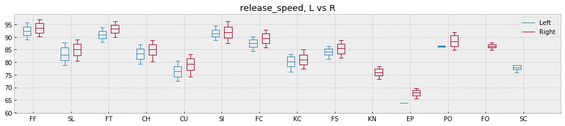

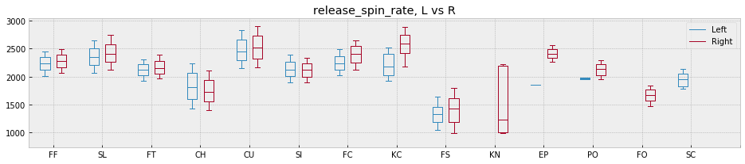

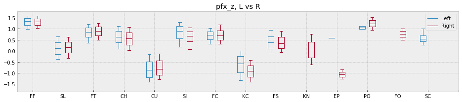

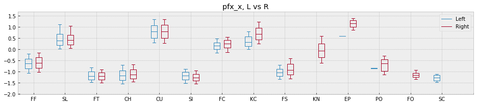

```python
# loop through columns and add grouped box plots
grapher.pitch_boxes(df, 'release_speed');
grapher.pitch_boxes(df, 'release_spin_rate');
grapher.pitch_boxes(df, 'pfx_z');
grapher.pitch_boxes(df, 'pfx_x');
```

# At Bats

Using the data we can replay individual at bats from 2018. An at bat is a single batter's turn to hit against a pitcher. During an at bat, the pitcher throws pitches to the batter, with each pitch being one of the following:

- strike - the pitch is in the "strike zone" (box indicated in the diagram), the batter swung and missed, or the batter hit the ball into foul territory
- ball - it is outside of the "strike zone" and the batter did not swing
- hit by pitch - the pitch hits the batter

The at bat continues until one of the following occurs:

- base on ball (a.k.a. walk) - the pitcher throws a total of 4 balls and the batter gets to go to first base
- strikeout - the pitcher throws 3 strikes and the batter is retired*
- ball in play (no out) - the batter makes contact with the pitch and no out is recorded
- ball in play (out) - the batter makes contact with the pitch and records a hit

* a batter cannot strikeout on a foul ball

## Chris Sale vs Aaron Judge

Now, let's look at an individual at bat and see what we can get out of the data. Let's look at Aaron Judge's at bat against Chris Sale on June 30th. Judge struck out on Sale's fastball.

The data has the location of the ball as it crosses the batters box. To define the vertical extent of the "strike zone" we use the mean values for `sz_top` and `sz_bot` across the entire year. The data does not contain the horizontal extent of the strike zone, so I have set it to be `[-1,1]`. In the graphic below, we show all pitches of the at-bat, colored by the result of the pitch, where `{'red': 'strike', 'green': 'ball', 'blue': 'ball in play'}` and the batter is indicated by the ellipse. Also, **whiffs** are outlined in black. A whiff is a pitch that was swung at by the batter, but no contact was made.

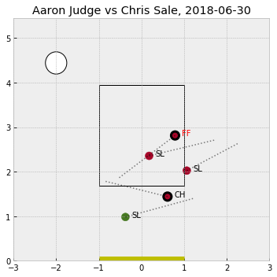

```python
player = 'Aaron Judge'
pitcher = 'Chris Sale'
date = '2018-06-30'
ab_num = 9

at_bat = df[(df['player_name']== player)
           & (df['pitch_name']== pitcher)
           & (df['game_date']== date)
           & (df['at_bat_number']== ab_num)]

grapher.at_bat(at_bat)
```

Looking at this, we see that Judge didn't swing at any of Sale's sliders, choosing to wait on a fastball. He swung at the changeup, most likely thinking it was a fastball, and then ultimately struck out a fastball.

Notice that there are 4 strikes here. That means that Aaron Judge fouled off a pitch.

## Blake Snell vs Aaron Judge

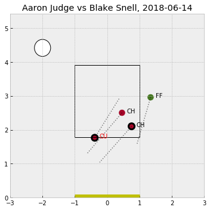

```python
player = 'Aaron Judge'
pitcher = 'Blake Snell'
date = '2018-06-14'
ab_num = 6

at_bat = df[(df['player_name']== player)
           & (df['pitch_name']== pitcher)
           & (df['game_date']== date)
           & (df['at_bat_number']== ab_num)]

grapher.at_bat(at_bat)
```

We can also look at an individual pitcher's set of pitches as they compare to other pitchers.

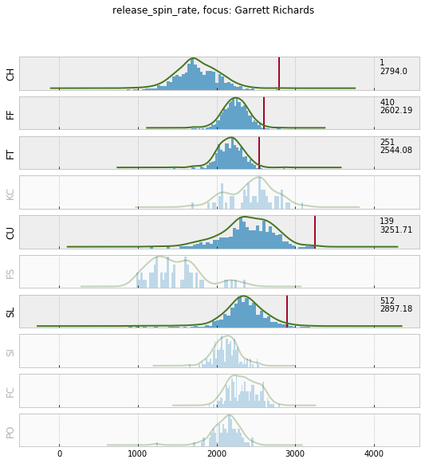

```python
ip = df.groupby(['pitch_name', 'game_date', 'inning']).size()
ip = ip.reset_index().groupby('pitch_name').size()
qualified = ip[ip>100]
pitcher = 'Garrett Richards'
col = 'release_spin_rate'

data = pitch_pitcher[pitch_pitcher[col].notnull()]
data = data.merge(df[['pitch_name', 'p_throws']].drop_duplicates().set_index('pitch_name'), left_on='pitch_name', right_index=True)
q = pitch_pitcher[pitch_pitcher[col].notnull()].reset_index().set_index('pitch_name').loc[qualified.index].reset_index().set_index('pitch_type')
valid = q.loc[q.groupby(q.index).size()>10].index.unique()

grapher.ridgeplot(data, valid, col, pitcher)
```

Now, let's add whiff rate to our analysis - Whiff% divides the number of pitches swung at and missed by the total number of swings in a given sample. This is usually a great indicator of the effectivness of a pitcher's pitch.

```python
outcomes = df['description'].unique()
swings = ['hit_into_play_score', 'foul', 'hit_into_play','swinging_strike', 'hit_into_play_no_out',
          'foul_tip', 'swinging_strike_blocked', 'swinging_pitchout', 'foul_pitchout']
missed = ['swinging_strike', 'swinging_strike_blocked', 'swinging_pitchout', 'foul_tip']

ppitch_types_swings = pd.DataFrame(
    df[df['description'].isin(swings)]
    .groupby(['pitch_type', 'pitch_name']).size()
    .sort_values(ascending=False), columns=['swings'])

ppitch_types_miss = pd.DataFrame(
    df[df['description'].isin(missed)]
    .groupby(['pitch_type', 'pitch_name']).size()
    .sort_values(ascending=False), columns=['missed'])

ppitch_types_count = pd.DataFrame(
    df.groupby(['pitch_type', 'pitch_name']).size()
    .sort_values(ascending=False), columns=['count'])

ppitch_types_pct = pd.DataFrame(
    df.groupby(['pitch_type', 'pitch_name']).size()
    .sort_values(ascending=False)/len(df), columns=['pct'])

pmovement = pd.DataFrame(
    df.groupby(['pitch_type', 'pitch_name'])['pfx_x', 'pfx_z', 'release_speed', 'release_spin_rate', 'babip_value']
    .apply(lambda c: c.mean()))

pitch_pitcher = pd.concat(
    [ppitch_types_swings, ppitch_types_miss, ppitch_types_count, ppitch_types_pct, pmovement], axis=1, sort=False)

pitch_pitcher['whiff_pct'] = pitch_pitcher['missed'] / pitch_pitcher['swings']
```

# ES Data Frame Analytics

Now, let's index the data into elasticsearch.

## Index Data

```python
host = 'http://localhost:9200'
es = Elasticsearch(hosts=[host])

# index data
def send_pitches():
    for m in df.reset_index().to_dict(orient='records'):
        yield {
            "_index": "mlb-2018",
            "_source":{
            k:v
            for k,v in m.items() if pd.notnull(v)
            }
        }
helpers.bulk(es, send_pitches())

# create the aggreagtor field
url = "/mlb-2018/_update_by_query"
config = {
    "script": {
        "lang": "painless",
        "source": "ctx._source.agger = ctx._source.pitch_type +'-' + ctx._source.pitch_name"
    },
    "query": {
        "match_all": {}
    }
}
es.update_by_query(body=config, index='mlb-2018')

# add swings and misses so we can calculate whiff
url = "/mlb-2018/_update_by_query"
config = {
  "script": {
    "lang": "painless",
    "source": "ctx._source.miss = 0"
  },
  "query": {
    "match_all": {}
  }
}
es.update_by_query(body=config, index='mlb-2018')

url = "/mlb-2018/_update_by_query"
config = {
  "script": {
    "lang": "painless",
    "source": "ctx._source.swing = 0"
  },
  "query": {
    "match_all": {}
  }
}
es.update_by_query(body=config, index='mlb-2018')

# updates swings and misses
url = "/mlb-2018/_update_by_query"
config = {
  "script": {
    "lang": "painless",
    "source": """
      if (['hit_into_play_score', 'foul', 'hit_into_play','swinging_strike', 'hit_into_play_no_out', 'foul_tip', 'swinging_strike_blocked', 'swinging_pitchout', 'foul_pitchout'].contains(ctx._source.description))
      { ctx._source.swing += 1}
    """
  }
}
es.update_by_query(body=config, index='mlb-2018')

# updates swings and misses
url = "/mlb-2018/_update_by_query"
config = {
  "script": {
    "lang": "painless",
    "source": """
      if (['swinging_strike', 'swinging_strike_blocked', 'swinging_pitchout', 'foul_tip'].contains(ctx._source.description))
      { ctx._source.miss += 1}
    """
  }
}
es.update_by_query(body=config, index='mlb-2018')
```

## Create Data Frame and Analytics

```python
def make_df(pitch, q=None):
    print("{} - creating df".format(pitch))
    host = 'http://localhost:9200'
    url = "/_data_frame/transforms/pitch_pitcher_{}".format(pitch)
    config = {
        "source": {
            "index": "mlb-2018",
            "query": {}
        },
        "dest": {
            "index": "pitch-pitcher-mlb-2018-{}".format(pitch)
        },
        "pivot": {
            "group_by": {
                "agger": {
                    "terms": {
                        "field": "agger.keyword"
                    }
                }
            },
            "aggregations": {
                "mean_pfx_x": {"avg": {"field": "pfx_x"}},
                "mean_pfx_z": {"avg": {"field": "pfx_z"}},
                "release_speed": {"avg": {"field": "release_speed"}},
                "release_spin_rate": {"avg": {"field": "release_spin_rate"}},
                "total_pitches": {"value_count": {"field": "pitch_number"}},
                "swings": {"sum": {"field": "swing"}},
                "misses": {"sum": {"field": "miss"}},
                "babip": {"avg": {"field": "babip_value"}}
            }
        }
    }

    if pitch == 'all':
        config['source']['query'] = {'match_all': {}}
    if pitch == 'all' and q:
        config['source']['query'] = {"terms": {"pitch_name.keyword": [p for p in q]}}
    if pitch.startswith('qual-'):
        config['source']['query'] = {
            "bool": {
                "must": [
                    {"match": {"pitch_type": pitch.replace('qual-','').upper()}},
                    {"terms": {"pitch_name.keyword": [p for p in q]}}
                ]
            }
        }
    else:
        config['source']['query'] = {'match': {"pitch_type": pitch.upper()}}
    print(requests.put(host+url, json=config).json())

def start_df(pitch):
    print("{} - starting df".format(pitch))
    host = 'http://localhost:9200'
    url = "/_data_frame/transforms/pitch_pitcher_{}/_start".format(pitch)
    print(requests.post(host+url).json())

def make_analytics(pitch):
    print("{} - starting analytics".format(pitch))
    host = 'http://localhost:9200'
    url = "/_ml/data_frame/analytics/nasty_pitches_{}".format(pitch)
    config = {
        "source": {
            "index": "pitch-pitcher-mlb-2018-{}".format(pitch),
            "query": {
                "range": {"total_pitches": {"gte": 100}}
            }
        },
        "dest": {
            "index": "pitch-pitcher-mlb-2018-outliers-{}".format(pitch)
        },
        "analysis": {
            "outlier_detection": {}
        },
        "analyzed_fields": {
            "includes": ["mean_pfx_x", "mean_pfx_z", "release_speed", "release_spin_rate"]
        }
    }
    print(requests.put(host+url, json=config).json())


def calculate_whiff(pitch):
    print("{} - calculating whiff".format(pitch))
    host = 'http://localhost:9200'
    es = Elasticsearch(host)
    url = "/pitch-pitcher-mlb-2018-{}/_update_by_query".format(pitch)
    config = {
        "script": {
            "lang": "painless",
            "source": """
            if (ctx._source.misses > 0)
            {ctx._source.whiff = ctx._source.misses / ctx._source.swings}
            """
        }
    }
    es.update_by_query(body=config, index='pitch-pitcher-mlb-2018-{}'.format(pitch))

def start_analytics(pitch):
    print("{} - starting analytics".format(pitch))
    host = 'http://localhost:9200'
    url = "/_ml/data_frame/analytics/nasty_pitches_{}/_start".format(pitch)
    print(requests.post(host+url).json())

def clean_up(pitch):
    """We need to do the following:
    1. delete transforms
    1. delete data frames
    2. delete outlier dataframes
    4. delete data frame analytics
    """

    # we need to delete data frames
    host = 'http://localhost:9200'

    # delete transforms
    tr_stop = "/_data_frame/transforms/pitch_pitcher_{}/_stop".format(pitch)
    tr_delete = "/_data_frame/transforms/pitch_pitcher_{}".format(pitch)
    print("{} - stopping transform".format(pitch))
    print(requests.post(host+tr_stop).json())
    time.sleep(10)
    print("{} - deleting transform".format(pitch))
    print(requests.delete(host+tr_delete).json())
    time.sleep(10)

    # delete dataframe
    df_delete = "/pitch-pitcher-mlb-2018-{}".format(pitch)
    print("{} - delete df".format(pitch))
    print(requests.delete(host+df_delete).json())
    time.sleep(10)

    # delete outlier dataframe
    o_delete = "/pitch-pitcher-mlb-2018-outliers-{}".format(pitch)
    print("{} - deleteing outlier df".format(pitch))
    print(requests.delete(host+o_delete).json())
    time.sleep(10)

    # delete dataframe analytics
    a_stop = "/_ml/data_frame/analytics/nasty_pitches_{}/_stop".format(pitch)
    a_delete = "/_ml/data_frame/analytics/nasty_pitches_{}".format(pitch)
    print("{} - stopping analytics".format(pitch))
    print(requests.post(host+a_stop).json())
    time.sleep(10)
    print("{} - deleting analytics".format(pitch))
    print(requests.delete(host+a_delete).json())
```

# Analysis

## All Pitches

```python
# create dataframe and analytics
make_df('all')
time.sleep(10)
start_df('all')
time.sleep(10)
calculate_whiff('all')
time.sleep(10)
make_analytics('all')
time.sleep(10)
start_analytics('all')
```

Let's look at the top outliers for all pitchers' pitches.

```python
res = es.search(index='pitch-pitcher-mlb-2018-outliers-all', sort=["ml.outlier_score:desc"], size=10000)
top = []
for i in res['hits']['hits']:
    pitch = {
        "pitch": i['_source']['agger'],
        "score": i['_source']['ml'],
        "pitches": i['_source']['total_pitches'],
        "babip": i['_source']['babip'],
        "whiff": i['_source']['whiff']
    }
    top.append(pitch)
```

```python
def highlight_row_max(s):
    s = s[:-2]
    is_max = s == s.max()
    sr = pd.Series([False, False])
    sr.index = ['whiff', 'babip']
    is_max = is_max.append(sr)
    return ['background-color: #eef44299' if v else '' for v in is_max]

outliers_all = pd.io.json.json_normalize(top)
outliers_all.columns = ['babip', 'pitch', 'pitches', 'fi.mean_pfx_x', 'fi.mean_pfx_z', 'fi.release_speed',
                        'fi.release_spin_rate', 'outlier_score', 'whiff']
outliers_all = outliers_all[['pitch', 'pitches', 'fi.mean_pfx_x', 'fi.mean_pfx_z', 'fi.release_speed',
                        'fi.release_spin_rate', 'outlier_score', 'whiff', 'babip']]
outliers_all = outliers_all.round(5)
outliers_all = outliers_all.set_index(['pitch', 'outlier_score', 'pitches'])
outliers_all.head(20).round(4).style.apply(highlight_row_max, axis=1).background_gradient(cmap='magma', subset=['whiff'], axis=0, low=0, high=1)
```

| pitch | outlier_score | pitches | fi.mean_pfx_x | fi.mean_pfx_z | fi.release_speed | fi.release_spin_rate | whiff | babip |
| --- | --- | --- | --- | --- | --- | --- | --- | --- |
| CU-Garrett Richards | 0.99576 | 139.0 | 0.0111 | 0.5404 | 0.0096 | 0.4389 | 0.3036 | 0.0645 |
| CH-Anibal Sanchez | 0.9924 | 126.0 | 0.0346 | 0.1016 | 0.7784 | 0.0854 | 0.3867 | 0.0781 |
| SL-Pat Venditte | 0.98705 | 127.0 | 0.1273 | 0.2211 | 0.3387 | 0.3129 | 0.3115 | 0.1724 |
| FS-Tony Sipp | 0.95698 | 109.0 | 0.0532 | 0.1026 | 0.4619 | 0.3824 | 0.5161 | 0.1379 |
| CU-Blaine Hardy | 0.94055 | 126.0 | 0.1916 | 0.2987 | 0.1437 | 0.3661 | 0.1304 | 0.1111 |
| CH-Alex Claudio | 0.93909 | 388.0 | 0.1958 | 0.2475 | 0.4361 | 0.1207 | 0.3264 | 0.2451 |
| FS-Blake Parker | 0.92651 | 356.0 | 0.0271 | 0.0897 | 0.3512 | 0.532 | 0.4068 | 0.092 |
| FF-Marco Estrada | 0.91759 | 1232.0 | 0.0081 | 0.7035 | 0.1762 | 0.1121 | 0.1688 | 0.194 |
| FS-Ryne Stanek | 0.91684 | 140.0 | 0.0325 | 0.0232 | 0.371 | 0.5733 | 0.5735 | 0.0444 |
| CU-Jackson Stephens | 0.89795 | 103.0 | 0.2801 | 0.08 | 0.2678 | 0.3721 | 0.3864 | 0.1852 |
| CU-Brad Ziegler | 0.85543 | 197.0 | 0.0799 | 0.0131 | 0.8906 | 0.0163 | 0.427 | 0.1207 |
| SL-Sergio Romo | 0.84671 | 655.0 | 0.0416 | 0.7034 | 0.1881 | 0.0668 | 0.3468 | 0.1894 |
| CU-Seth Lugo | 0.83873 | 513.0 | 0.1208 | 0.3017 | 0.0294 | 0.548 | 0.2533 | 0.1544 |
| SL-Tyler Glasnow | 0.81024 | 190.0 | 0.3549 | 0.2871 | 0.2274 | 0.1306 | 0.5652 | 0.0563 |
| SL-Adam Morgan | 0.8066 | 354.0 | 0.0965 | 0.1683 | 0.1147 | 0.6205 | 0.3819 | 0.1687 |
| CU-Rich Hill | 0.79706 | 758.0 | 0.5148 | 0.0458 | 0.0706 | 0.3688 | 0.2105 | 0.1831 |
| CH-Marco Estrada | 0.77417 | 924.0 | 0.1213 | 0.4368 | 0.3731 | 0.0688 | 0.3239 | 0.1956 |
| FS-Jake Faria | 0.77202 | 208.0 | 0.0432 | 0.0833 | 0.4788 | 0.3946 | 0.3238 | 0.1774 |
| SL-Kyle Crick | 0.75823 | 270.0 | 0.1321 | 0.095 | 0.0711 | 0.7018 | 0.4364 | 0.0781 |
| CU-Ryan Pressly | 0.73495 | 306.0 | 0.071 | 0.6242 | 0.0565 | 0.2484 | 0.3542 | 0.1667 |

### Garrett Richards - Curveball

The most outlying pitch of all 2018 is Garret Richard's Curveball, with the highest contributing factors being its vertical movement and it's spin rate.

```python
from IPython.display import HTML

HTML('<iframe width="800" height="500" src="https://www.mlb.com/angels/video/statcast-richards-filthy-curve-c2134014183?autoplay=false" frameborder="0"></iframe>')
```

[interactive chart not shown]

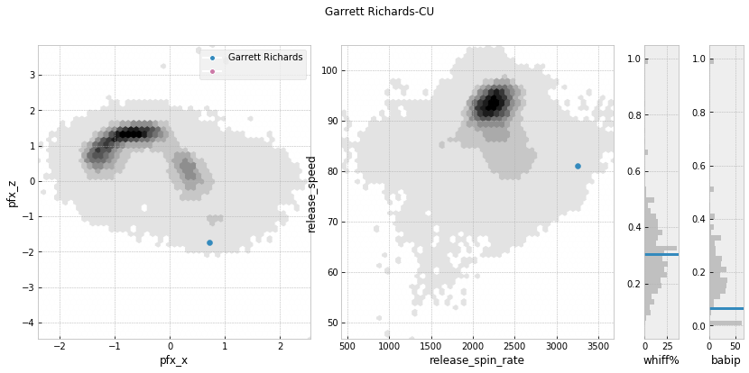

```python
pitcher = 'Garrett Richards'
p_throws = 'R'
pitch = 'CU'
grapher.hexes(df, pitch_pitcher, p_throws, pitch, pitcher)
```

### Pat Venditte

[figure not shown]

**A switch-pitcher -- very rare**

## Partition Analyses by Pitch Type

Let's create separate dataframes for each pitch type so we can run analytics separately.

```python
# get all unique pitches

body = {
    "size": 0,
    "aggs": {
        "unique_pitches": {
            "terms": {
                "field": "pitch_type.keyword",
                "size": 100
            }
        }
    }
}

res = es.search(index="mlb-2018", body=body)

pitches = []
for hit in res['aggregations']['unique_pitches']['buckets']:
    if hit['doc_count'] > 1000:
        pitches.append(hit['key'].lower())
```

```python
# create dataframe and run analytics for each

for pitch in pitches:
    print("{}...analyzing".format(pitch))
    clean_up(pitch)
    time.sleep(10)
    make_df(pitch)
    time.sleep(10)
    start_df(pitch)
    time.sleep(10)
    calculate_whiff(pitch)
    time.sleep(10)
    make_analytics(pitch)
    time.sleep(10)
    start_analytics(pitch)
    time.sleep(10)
```

```python
# inspect results in pandas dataframes

pitch_outliers = {}

for p in pitches:
    pitch_outliers[p] = True
    res_top_20 = es.search(index='pitch-pitcher-mlb-2018-outliers-{}'.format(p), sort=["ml.outlier_score:desc"], size=10000)
    top_20 = []
    for i in res_top_20['hits']['hits']:
        pitch = {
            "pitch": i['_source']['agger'],
            "score": i['_source']['ml'],
            "pitches": i['_source']['total_pitches'],
            "babip": i['_source']['babip'],
            "whiff": i['_source']['whiff']
        }
        top_20.append(pitch)

    pitch_outliers[p] = pd.io.json.json_normalize(top_20)
    pitch_outliers[p].columns = ['babip', 'pitch', 'pitches', 'fi.mean_pfx_x', 'fi.mean_pfx_z', 'fi.release_speed',
                        'fi.release_spin_rate', 'outlier_score', 'whiff']
    pitch_outliers[p] = pitch_outliers[p][['pitch', 'pitches', 'fi.mean_pfx_x', 'fi.mean_pfx_z', 'fi.release_speed',
                        'fi.release_spin_rate', 'outlier_score', 'whiff', 'babip']]
    pitch_outliers[p].head(10)
    pitch_outliers[p] = pitch_outliers[p].round(5)
    pitch_outliers[p] = pitch_outliers[p].set_index(['pitch', 'outlier_score', 'pitches'])
```

```python
pitch_outliers['sl'].head(15).round(4).style.apply(highlight_row_max, axis=1).background_gradient(cmap='magma', subset=['whiff'], axis=0, low=0, high=0.5)
```

| pitch | outlier_score | pitches | fi.mean_pfx_x | fi.mean_pfx_z | fi.release_speed | fi.release_spin_rate | whiff | babip |
| --- | --- | --- | --- | --- | --- | --- | --- | --- |
| SL-Pat Venditte | 0.99523 | 127.0 | 0.0551 | 0.0091 | 0.8871 | 0.0488 | 0.3115 | 0.1724 |
| SL-Tyler Glasnow | 0.98278 | 190.0 | 0.0316 | 0.589 | 0.0165 | 0.3628 | 0.5652 | 0.0563 |
| SL-Joe Smith | 0.89858 | 238.0 | 0.026 | 0.7961 | 0.1756 | 0.0023 | 0.3438 | 0.0702 |
| SL-Alex Claudio | 0.83676 | 124.0 | 0.0494 | 0.3912 | 0.4086 | 0.1508 | 0.451 | 0.2857 |
| SL-Dellin Betances | 0.76117 | 192.0 | 0.0208 | 0.7181 | 0.234 | 0.0271 | 0.3736 | 0.0682 |
| SL-Clayton Kershaw | 0.73304 | 968.0 | 0.3084 | 0.4437 | 0.0584 | 0.1894 | 0.2589 | 0.1492 |
| SL-Sergio Romo | 0.71216 | 655.0 | 0.0139 | 0.0374 | 0.0648 | 0.8838 | 0.3468 | 0.1894 |
| SL-Kyle Crick | 0.68792 | 270.0 | 0.0396 | 0.0428 | 0.0121 | 0.9055 | 0.4364 | 0.0781 |
| SL-Adam Morgan | 0.68696 | 354.0 | 0.3318 | 0.3685 | 0.0505 | 0.2493 | 0.3819 | 0.1687 |
| SL-Cory Gearrin | 0.64134 | 346.0 | 0.0242 | 0.5216 | 0.1587 | 0.2955 | 0.3974 | 0.1222 |
| SL-Jordan Hicks | 0.62949 | 280.0 | 0.4356 | 0.4129 | 0.1242 | 0.0273 | 0.5182 | 0.0933 |
| SL-Mike Fiers | 0.5929 | 465.0 | 0.0265 | 0.6359 | 0.311 | 0.0265 | 0.1351 | 0.2155 |
| SL-Noah Syndergaard | 0.58858 | 503.0 | 0.01 | 0.0346 | 0.9367 | 0.0187 | 0.4613 | 0.1942 |
| SL-Ray Black | 0.58207 | 126.0 | 0.0828 | 0.2415 | 0.102 | 0.5736 | 0.4348 | 0.0588 |
| SL-Brett Anderson | 0.57186 | 303.0 | 0.054 | 0.6515 | 0.1481 | 0.1464 | 0.2981 | 0.2353 |

### Tyler Glasnow

[figure not shown]

### Mike Fiers

To quote forbes:

> Hands down, the worst qualifying pitch of 2018 was Mike Fiers' slider, which earned a D grade.

Why was this one so bad?

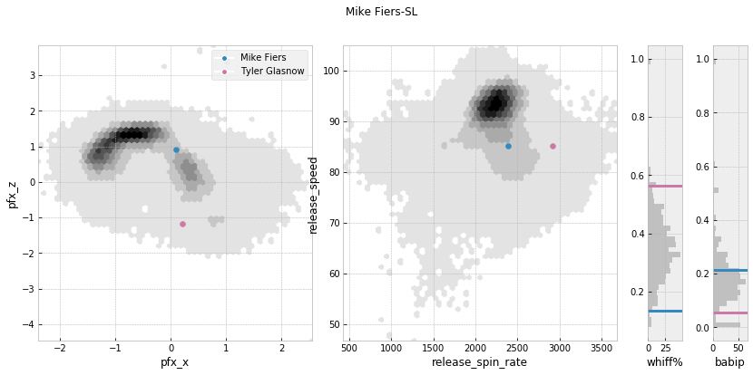

```python
pitcher = 'Mike Fiers'
pitcher2 = 'Tyler Glasnow'
p_throws = 'R'
pitch = 'SL'
grapher.hexes(df, pitch_pitcher, p_throws, pitch, pitcher, pitcher2)
```

Comparing Mike Fiers and Tyler Glasnow, we see that Glasnow's sliders are thrown with a much greater rotation, and a much more signifcant vertical drop.

# Wherefore Cy Young Winners?

At the end of the year, the MLB hands out two Cy Young awards for the best pitcher in each league, last year the awards were won by Jacob deGrom of the Mets and Blake Snell of the Tampa Bay Rays. Let's see how their arsenal compares to the rest of the league.

## Jacob deGrom

Jacob deGrom is known for his fastball (`FF`).

```python
outliers_all.filter(like='Jacob deGrom', axis=0)
```

| pitch | outlier_score | pitches | fi.mean_pfx_x | fi.mean_pfx_z | fi.release_speed | fi.release_spin_rate | whiff | babip |
| --- | --- | --- | --- | --- | --- | --- | --- | --- |
| SL-Jacob deGrom | 0.04279 | 770.0 | NaN | NaN | NaN | NaN | 0.36090 | 0.17105 |
| CU-Jacob deGrom | 0.02486 | 255.0 | NaN | NaN | NaN | NaN | 0.34444 | 0.22917 |
| FT-Jacob deGrom | 0.01812 | 295.0 | NaN | NaN | NaN | NaN | 0.12179 | 0.20408 |
| FF-Jacob deGrom | 0.01605 | 1374.0 | NaN | NaN | NaN | NaN | 0.31946 | 0.17231 |
| CH-Jacob deGrom | 0.00878 | 516.0 | NaN | NaN | NaN | NaN | 0.33948 | 0.11852 |

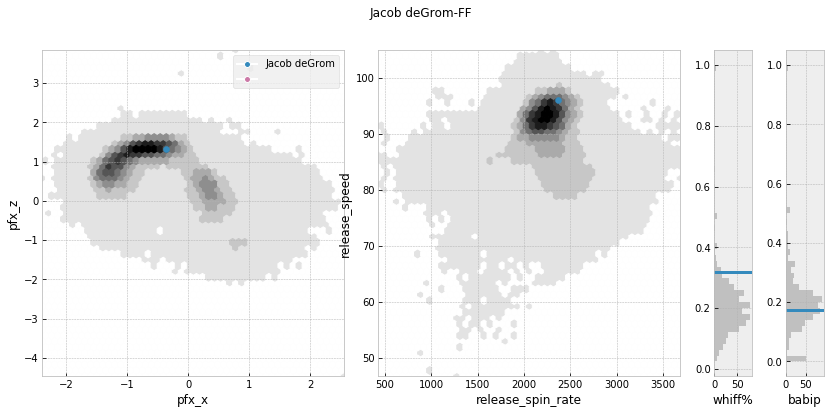

```python
pitcher = 'Jacob deGrom'
p_throws = 'R'
pitch = 'FF'
grapher.hexes(df, pitch_pitcher, p_throws, pitch, pitcher)
```

However, his fastballs are perfectly average! His dominance can't be explained with the features we've sleected. deGroms' success most likley comes from his impeccable command and his ability to mix up pitches and beating batters in the mental game.

# Blake Snell

```python
outliers_all.filter(like='Blake Snell', axis=0)
```

| pitch | outlier_score | pitches | fi.mean_pfx_x | fi.mean_pfx_z | fi.release_speed | fi.release_spin_rate | whiff | babip |
| --- | --- | --- | --- | --- | --- | --- | --- | --- |
| FF-Blake Snell | 0.14203 | 1500.0 | 0.20837 | 0.05387 | 0.59692 | 0.14084 | 0.25000 | 0.16199 |
| SL-Blake Snell | 0.13572 | 266.0 | 0.48171 | 0.18924 | 0.27722 | 0.05183 | 0.48276 | 0.06897 |
| CH-Blake Snell | 0.08952 | 559.0 | NaN | NaN | NaN | NaN | 0.31047 | 0.14483 |
| CU-Blake Snell | 0.07638 | 588.0 | NaN | NaN | NaN | NaN | 0.53430 | 0.11644 |

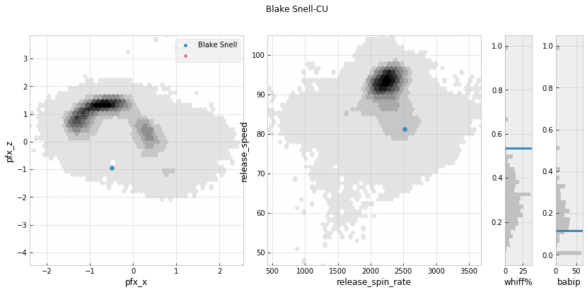

```python
pitcher = 'Blake Snell'
p_throws = 'R'
pitch = 'CU'
grapher.hexes(df, pitch_pitcher, p_throws, pitch, pitcher)
```

Blake Snell's curveball was known to be one of the most dominant pitches of 2018, but according to our analysis, it doesn't seem all that outlying. This likely has to do with the fact that an outstanding pitch needs to be contextualized. So much of pitching is about control, mixing up pitches, and throwing the right pitch at the right time.

> "I think it's just mainly because of how hard he throws his fastball," Blue Jays catcher Luke Maile said. "It comes out of the same slot, he's got that angle and that kind of upshot heater, and that breaking ball kind of starts out as something you need to hit. Then, before you know it, he threw it 55 feet."

# Results

In this analysis, we've managed to highlight a few pitchs both good, and bad. Some that are completely unique, and some thrown by pitchers with rare abilities. However, we learned that the Cy Young winners we're not all that different from the rest of the pack when looking at pysical factors of their pitches.

So, there's more to pitching that unusual physical factors of the pitch. To quote Yogi Berra:

> Baseball is 90% mental, the other half is physical.

There are also a lot of important situational details that make a pitcher effective. To name a few:

- first pitch strikes
- babip
- contact/hard contact
- mixing up pitches - mental

Identifying a truly outstanding pitch and pitcher take into account all of these features, and looks at how they progress over time. In a subsequent analysis, we can dig deeper into this rich dataset and try to uniquely identify Blake Snell and Jacob deGrom's award winning seasons.